# Section 4: Partial Derivatives of Multivariable Functions

Understanding Multivariable Calculus in Business Applications

Calculus Lecture Series

2026-08-13

```r
library(htmltools)

APP_URL <- "https://pchen-aitutor.hf.space"  # ← your Gradio app URL
USER_ID <- "anonymous_user"

browsable(tagList(
  # --- styles (fab, bubble, modal) ---
  tags$style(HTML("
    #tutor-fab{position:fixed;right:20px;bottom:20px;z-index:99999;padding:12px 14px;border-radius:999px;border:1px solid #ddd;background:#fff;box-shadow:0 8px 24px rgba(0,0,0,.15);cursor:pointer;font-weight:600}
    #tutor-fab:hover{background:#f6f8ff}
    #tutor-sel-btn{position:absolute;display:none;z-index:100000;padding:6px 10px;font-size:12px;border:1px solid #e5e7eb;border-radius:10px;background:#111827;color:#f9fafb;box-shadow:0 8px 24px rgba(0,0,0,.2);cursor:pointer;user-select:none}
    #tutor-modal-overlay{display:none;position:fixed;z-index:99998;inset:0;background:rgba(0,0,0,.35)}
    #tutor-modal{position:absolute;top:5%;left:50%;transform:translateX(-50%);width:min(980px,95vw);height:min(720px,90vh);background:#fff;border-radius:10px;box-shadow:0 10px 30px rgba(0,0,0,.25);overflow:hidden}
    #tutor-modal-header{display:flex;justify-content:space-between;align-items:center;padding:10px 14px;background:#f5f5f7;border-bottom:1px solid #e5e5ea;font-weight:600}
    #tutor-close-btn{cursor:pointer;border:none;background:transparent;font-size:18px}
    #tutor-iframe{width:100%;height:calc(100% - 18px);border:0}
  ")),

  # modal + iframe
  tags$div(id="tutor-modal-overlay",
    tags$div(id="tutor-modal",
      tags$div(id="tutor-modal-header","AI Calculus Tutor", tags$button(id="tutor-close-btn","✕")),
      tags$iframe(id="tutor-iframe", src="")
    )
  ),

  # floating button + selection bubble
  tags$button(id="tutor-fab","Ask Tutor"),
  tags$button(id="tutor-sel-btn","Ask Tutor"),

  # script
  tags$script(HTML(sprintf("
    (function(){
      const APP_URL = '%s';
      const USER_ID = '%s';

      function sel(){ try { return (window.getSelection?window.getSelection().toString():'').trim(); } catch(e){ return ''; } }
      function openInline(q, action){
        const p = new URLSearchParams({ user_id: USER_ID, q: q||'', action: action||'prefill' });
        const frame = document.getElementById('tutor-iframe');
        frame.src = APP_URL + '/?' + p.toString();          // Prefill handled by app from URL
        document.getElementById('tutor-modal-overlay').style.display='block';
      }
      function openTab(q, action){
        const p = new URLSearchParams({ user_id: USER_ID, q: q||'', action: action||'prefill' });
        window.open(APP_URL + '/?' + p.toString(), 'ai_tutor_tab', 'noopener');
      }

      // floating button: prefill by default; Alt=send; Ctrl/Cmd=new tab
      document.getElementById('tutor-fab').addEventListener('click', function(ev){
        const q = sel();
        const act = ev.altKey ? 'send' : 'prefill';
        if (ev.ctrlKey || ev.metaKey) openTab(q, act); else openInline(q, act);
      });

      // selection bubble near highlighted text
      const b = document.getElementById('tutor-sel-btn');
      let last='';
      function place(x,y){ b.style.left=(x+10)+'px'; b.style.top=(y+10)+'px'; }
      function show(){ b.style.display='block'; } function hide(){ b.style.display='none'; }
      document.addEventListener('mouseup', e => setTimeout(() => {
        const t = sel(); if (t && t.length>=2 && t.length<=800){ last=t; place(e.pageX,e.pageY); show(); } else hide();
      }, 20));
      window.addEventListener('scroll', hide, {passive:true}); window.addEventListener('resize', hide);

      // bubble click: prefill by default; Alt=send; Ctrl/Cmd=new tab
      b.addEventListener('click', function(ev){
        if (!last) return;
        const act = ev.altKey ? 'send' : 'prefill';
        if (ev.ctrlKey || ev.metaKey) openTab(last, act); else openInline(last, act);
        hide();
      });

      // close modal
      const overlay = document.getElementById('tutor-modal-overlay');
      document.getElementById('tutor-close-btn').addEventListener('click', () => overlay.style.display='none');
      overlay.addEventListener('click', e => { if (e.target===overlay) overlay.style.display='none'; });
    })();
  ", APP_URL, USER_ID)))
))
```

AI Calculus Tutor

[interactive chart not shown]

# Learning Objectives

By the end of this section, students will be able to:

1. **Interpret higher-order derivatives** and their practical significance
2. **Understand partial derivatives** and their relationship to total derivatives in multivariable functions
3. **Calculate higher-order partial derivatives** and understand their economic interpretations
4. **Find local maximum and minimum** using first-order and second-order conditions for multivariable functions

R skills

1. Solving multivariable optimisation problems using R `optim()`
2. Verifying local optimum using 3D plot

# Knowledge Point 4.1: Higher Order Derivatives and Their Interpretation

## Multiple Perspectives on the Same Reality

One of the most powerful aspects of derivatives is that they provide **alternative ways** to describe the same phenomenon. Just as a building can be described by its blueprint, elevation view, or 3D model, real-world processes can be described through different mathematical relationships.

## Example 4.1: The Growing Company

Consider TechStart Inc., a rapidly growing technology company. We can describe their growth story in multiple ways:

1. **Total employees over time:** $E(t) = 50 + 20t + 2t^2$ (where $t$ is years since founding)
2. **Rate of hiring:** $(E(t))' = E'(t) = 20 + 4t$ (new employees per year, derivative of $E(t)$)
3. **Acceleration of growth:** $(E'(t))' = E''(t) = 4$ (how the hiring rate itself changes,derivative of $E'(t)$

Each perspective reveals different insights: - The **total** tells us company size at any time - The **rate** tells us how aggressively they’re expanding - The **acceleration** tells us if growth is speeding up or slowing down

## Motion Analysis

For position function $s(t)$:

- **Position:** $s(t)$ (where the object is)
- **Velocity:** $v(t) = s'(t)$ (how fast it’s moving, derivative of $s(t)$
- **Acceleration:** $a(t) = v'(t) = s''(t)$ (how velocity changes, derivative of the derivative of $s(t)$)

[figure not shown]

Experiment of the Inclined Plane

[interactive chart not shown]

## Beyond the First Derivative

From the study above, we know derivative of a function is itself a function, we can take the derivative of the derivative, and so on. These **higher-order derivatives** provide deeper insights into the behavior of functions and the phenomena they represent.

## Example 4.2: The Rocket Launch

Consider a rocket launching into space. At any moment, we can describe its motion using multiple levels of analysis:

1. **Position:** $s(t)$ - How high the rocket is
2. **Velocity:** $v(t) = s'(t)$ - How fast it’s climbing
3. **Acceleration:** $a(t) = v'(t) = s''(t)$ - How quickly its speed is changing
4. **Jerk:** $j(t) = a'(t) = s'''(t)$ - How smoothly the acceleration changes

Each derivative reveals a different aspect of the rocket’s motion, from basic location to the smoothness of its flight.

**Definition 4.1 (Higher-Order Derivatives):** For a function $f(x)$:

- **First derivative:** $f'(x) = \frac{df}{dx}$
- **Second derivative:** $f''(x) = \frac{d^2f}{dx^2} = \frac{d}{dx}[f'(x)]$
- **Third derivative:** $f'''(x) = \frac{d^3f}{dx^3} = \frac{d}{dx}[f''(x)]$
- **nth derivative:** $f^{(n)}(x) = \frac{d^nf}{dx^n}$

### Geometric Interpretation of the Second Derivative

The second derivative tells us about the **curvature** of a function:

- $f''(x) > 0$: Function is **concave up** (curves upward like ∪)
- $f''(x) < 0$: Function is **concave down** (curves downward like ∩)
- $f''(x) = 0$: Possible **inflection point** (curvature changes)

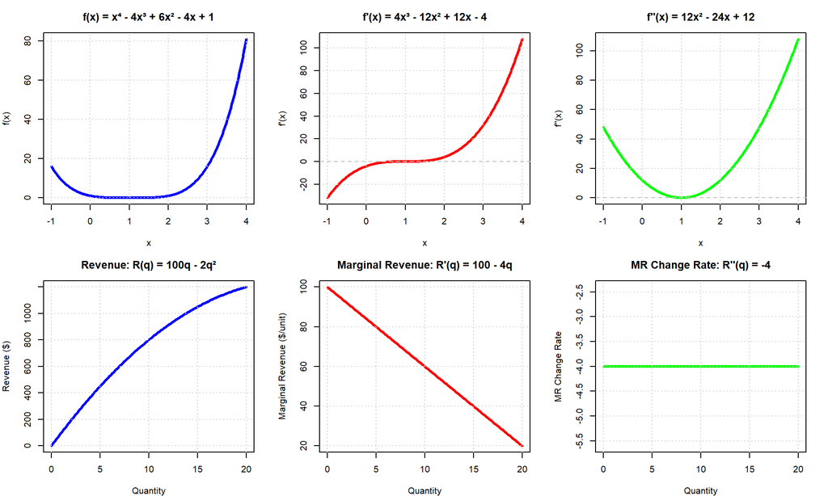

Higher Order Derivatives and Function Behavior

```r
par(mfrow = c(2, 3), mar = c(4, 4, 3, 2))

# Example function: f(x) = x^4 - 4x^3 + 6x^2 - 4x + 1
x <- seq(-1, 4, by = 0.01)
f <- x^4 - 4*x^3 + 6*x^2 - 4*x + 1
f_prime <- 4*x^3 - 12*x^2 + 12*x - 4
f_double_prime <- 12*x^2 - 24*x + 12
f_triple_prime <- 24*x - 24

# Original function
plot(x, f, type = "l", lwd = 3, col = "blue",
     main = "f(x) = x⁴ - 4x³ + 6x² - 4x + 1",
     xlab = "x", ylab = "f(x)")
grid()

# First derivative
plot(x, f_prime, type = "l", lwd = 3, col = "red",
     main = "f'(x) = 4x³ - 12x² + 12x - 4",
     xlab = "x", ylab = "f'(x)")
abline(h = 0, col = "gray", lty = 2)
grid()

# Second derivative
plot(x, f_double_prime, type = "l", lwd = 3, col = "green",
     main = "f''(x) = 12x² - 24x + 12",
     xlab = "x", ylab = "f''(x)")
abline(h = 0, col = "gray", lty = 2)
grid()

# Business example: Revenue function
q <- seq(0, 20, by = 0.1)
revenue <- 100*q - 2*q^2
marginal_revenue <- 100 - 4*q
mr_change <- rep(-4, length(q))

plot(q, revenue, type = "l", lwd = 3, col = "blue",
     main = "Revenue: R(q) = 100q - 2q²",
     xlab = "Quantity", ylab = "Revenue ($)")
grid()

plot(q, marginal_revenue, type = "l", lwd = 3, col = "red",
     main = "Marginal Revenue: R'(q) = 100 - 4q",
     xlab = "Quantity", ylab = "Marginal Revenue ($/unit)")
abline(h = 0, col = "gray", lty = 2)
grid()

plot(q, mr_change, type = "l", lwd = 3, col = "green",
     main = "MR Change Rate: R''(q) = -4",
     xlab = "Quantity", ylab = "MR Change Rate")
abline(h = 0, col = "gray", lty = 2)
text(10, -2, "Constant decrease in MR", col = "green")
grid()
```

```r
par(mfrow = c(1, 1))
```

### Business Analysis

For profit function $\pi(q)$:

**Production Function:** $Q(L)$

- $Q'(L)$: Marginal product of labor. It is the additional units of output for one additional unit of input.
- $Q''(L)$: Rate of change of marginal product
  - $Q''(L) < 0$: **Diminishing marginal returns, or the law of diminishing returns**
  - $Q''(L) > 0$: **Increasing marginal returns**

**Cost Function:** $C(q)$

- $C'(q)$: Marginal cost. It is the additional cost for one more unit of output.
- $C''(q)$: Rate of change of marginal cost
  - $C''(q) > 0$: **Increasing marginal cost** (typical)
  - $C''(q) < 0$: **Decreasing marginal cost** (economies of scale)
- **Total Profit:** $\pi(q)$ (profit at production level $q$)
- **Marginal Profit:** $MP(q) = \pi'(q)$ (additional profit from one more unit of output)
- **Profit Acceleration:** $\pi''(q)$ (how marginal profit changes)

### Economic Analysis

**For price level** $P(t)$:

- **CPI:** $P(t)$ (price leval at time $t$)
- **Inflation rate:** $\pi(t) = P'(t)$ (growth rate of CPI)
- **disinflation:** $\pi'(q)<0$ (inflation rate slows down)

** For consumer behaviour** $U(x)$:

- $U'(x)$: Marginal utility
- $U''(x)$: Rate of change of marginal utility
  - $U''(x) < 0$: **Diminishing marginal utility** (typical consumer behavior)

## Application of Second order Derivative for Local Extrema

### Second-Order Test

**Step 1**: find the critical points

solve:
$$f'(x)=0$$

**Step 2**: Apply second derivative test

Evaluate $f''(x)$ at each critical point $x_0$

- $f''(x_0)>0$: local minimum
- $f''(x_0)<0$: local maximum
- $f''(x_0)=0$: inconclusive

### Example 4.3 Profit maximisation

A firm’s profit from selling a product is modeled bY;
$$\pi(p) = -2p^2 +40p -100$$
where $p$ is the price per unit.

- First derivative:
  $$\pi'(p) = -4p +
  40\hspace{1cm}\to\hspace{0.5cm}p=10$$
- Second derivative:
  $$\pi''(p)=-4<0$$
  So, $p=10$ gives a local maximum.

### Connection between the first derivative test and the second derivative test:

| **Aspect** | **First Derivative Test** | **Second Derivative Test** |
| --- | --- | --- |
| **Key Condition** | $f'(x)$ changes sign at a critical point | $f'(x_0) = 0$ and $f''(x_0) \neq 0$ |
| **Local Maximum** | $f'(x)$ changes from positive to negative | $f''(x_0) < 0$ |
| **Local Minimum** | $f'(x)$ changes from negative to positive | $f''(x_0) > 0$ |
| **No Extremum** | No sign change in $f'(x)$ | $f''(x_0) = 0$: Test is inconclusive |

### Graphical presentation of a function and its derivatives

You can use the following interactive diagram to investigate the relation between a function and its first and second order derivatives. You can input you own functions for investigation.

# Calculus Zoom Explorer

Zoom in to see how a curve becomes locally linear. The background is colored by which side of the tangent the curve lies on.

Tangent (1st order) Curvature (2nd order) Tangent halves

[interactive chart not shown]

Zoom level

Focus point x₀

f(x)

Tangent

2nd-order

Curve side

Other side

f″=0 (same both sides)

x₀ = 0.0000, f(x₀) = 0.0000, f′(x₀) = 1.0000, f″(x₀) = 0.0000

## Function & Derivatives Visualization

### Exercise

Calculate the first and the second derivative of a function $f$, say $f(x)= x^4-4^3-x^2-8$ numerically, and draw the curves of $f(x)$, $f'(x)$, and $f''(x)$ in one plot. You can use `ylim=c(high,low)` to adjust the scale of the graph in the vertical direction. Complete the task in following R Environment or in your local RStudio.

[interactive chart not shown]

## Interactive Quiz 4.1a

## Interactive Quiz 4.1b

# Multivariable Functions

We use multivariable functions to describe the relation among many inputs and one output, such as a company’s profit depends on multiple factors: production levels of different products, labor allocation, capital investment, marketing expenditure, and market prices.

How can we extend the derivative concept to multivariable cases and how can we find maximum or minimum of a multivariable function?

# Knowledge Point 4.2: Partial Derivatives and Total Derivatives

### Example 4.4: The Coffee Shop Revenue Model

Imagine Sarah owns a coffee shop that sells two main products: coffee and pastries. Her daily revenue depends on both the number of cups of coffee sold $q_1$ and the number of pastries sold $q_2$. Through market research, she has determined that her revenue function is:
$$R(q_1, q_2) = 100q_1 + 150q_2 - 0.5q_1^2 -
0.8q_2^2 + 0.3q_1q_2$$

Sarah wants to understand how her revenue changes when she sells one more cup of coffee, holding pastry sales constant. She also wants to know how revenue changes when she sells one more pastry, holding coffee sales constant. These questions lead naturally to the concept of partial derivatives.

The partial derivative of revenue with respect to coffee sales $∂R/∂q_1$ that is the derivative of $R$ with respect to $q_1$ while treating $q_2$ as a constant tells Sarah how much additional revenue she can expect from selling one more cup of coffee, assuming pastry sales remain unchanged. Similarly, the partial derivative with respect to pastry sales $∂R/∂q_2$ shows the marginal revenue from one additional pastry.

But Sarah also realizes that in reality, when she changes her coffee marketing strategy, it might affect pastry sales too. The total change in revenue when both variables change simultaneously requires understanding total derivatives and the chain rule for multivariable functions.

**Definition 4.2 (Partial Derivative):** For a function $f(x, y)$ of two variables, the partial derivative with respect to $x$ is defined as:

$$\frac{\partial f}{\partial x} = \lim_{h
\to 0} \frac{f(x + h, y) - f(x, y)}{h}$$

Similarly, the partial derivative with respect to y is:

$$\frac{\partial f}{\partial y} = \lim_{h
\to 0} \frac{f(x, y + h) - f(x, y)}{h}$$

**Key Insight:** When computing $∂f/∂x$, we treat y as a constant. When computing $∂f/∂y$, we treat $x$ as a constant. This is the similar approach when we use slice to visualise a multivariable function, where we fix the value other input variables and focus on the influence of changes of one input variable on the output variable. It can be seen as the rate of change of a slice curve.

**Notation:** Partial derivatives can be written in several equivalent ways:

- $∂f/∂x = f_x = f_1$
- $∂f/∂y = f_y = f_2$

**Definition 4.3 (Total Differential):** The total differential of f(x, y) is:

$$df = \frac{\partial f}{\partial x} dx +
\frac{\partial f}{\partial y} dy$$

This represents the approximate change in $f$ when $x$ changes by $dx$ and $y$ changes by $dy$.

**Definition 4.4 Gradient** The vector of the partial derivatives is called gradient denoted as follows.
$$\nabla f = \left( \frac{\partial f}{\partial x},
\frac{\partial f}{\partial y} \right)'$$
For univariable functions, the sign of the first derivative at a point indicates whether the function is increasing or decreasing as the variable $x$ increases.

For multivariable functions, a positive partial derivative with respect to a variable means the function increases as that variable increases, and vice versa.

Level curves (or contour lines) represent points where the function has the same value, so there is no change in height along a level curve.

The gradient vector at a point is always perpendicular to the level curve at that point and points in the direction of the steepest ascent.

**A gradient field** is a map that puts an arrow at every point. This arrow points in the direction of the steepest ascent (greatest increase) of the function $f$ at that point, and its magnitude (length) represents the rate (or slope) of that steepest ascent.

### Visualisation of partial derivatives and gradient.

[interactive chart not shown]

Check only the box of Show x-slice and tangent $(y-y_0)$, you can see the partial derivative with respect to $x$ is the slope of the of the tangent line of the x-slice curve at $y=y_0$. Then check the box of Show y-slice and tangent $(x-x_0)$ the partial derivative with respect to $y$ is the slope of the tangent line of the y-slice curve at $x=x_0$. Check the box of Show tangent plane, you will see the two partial derivatives determine the tangent plane (remember: a plane is determined by a point $(x_0,y_0)$ and the slopes in two directions, $\frac{\partial f}{\partial x}$ and $\frac{\partial f}{\partial y}$. Check the box of Show gradient arrow, you will see the arrow is always on the tangent plane and walays points to the direction of the steepest ascent.

You can use the slider of $x_0$ and $y_0$ to change the point at which the partial derivatives are calculated.

### Computing Partial Derivatives

For the coffee shop revenue function $R(q_1, q_2) = 100q_1 + 150q_2 - 0.5q_1^2 - 0.8q_2^2 + 0.3q_1q_2$:

**Partial derivative with respect to $q_1$:** (Here we take $q_2$ as a constant.)
$$\frac{\partial R}{\partial q_1} = 100 - q_1 +
0.3q_2$$

**Partial derivative with respect to $q_2$:**(Here we take $q_1$ as a constant.)
$$\frac{\partial R}{\partial q_2} = 150 - 1.6q_2 +
0.3q_1$$

### Economic Interpretation

In economic terms:

- $∂R/∂q_1$ represents the **marginal revenue from coffee** when pastry sales are held constant
- $∂R/∂q_2$ represents the **marginal revenue from pastries** when coffee sales are held constant
- The cross-partial term $0.3q_1q_2$ indicates that coffee and pastries are **complementary products** (selling more of one increases the marginal revenue of the other)

### Business Applications

**Production Functions:** For a Cobb-Douglas production function $Q(L, K) = AL^α K^β$:

- $∂Q/∂L = αAL^{(α-1)}K^β$ (marginal product of labor)
- $∂Q/∂K = βAL^α K^{(β-1)}$ (marginal product of capital)

**Utility Functions:** For a utility function $U(x, y) = x^α y^β$:

- $∂U/∂x = αx^{(α-1)}y^β$ (marginal utility of good $x$)
- $∂U/∂y = βx^α y^{(β-1)}$ (marginal utility of good $y$)

**Cost Functions:** For a cost function $C(q_1, q_2)$ representing the cost of producing quantities $q_1$ and $q_2$:

- $∂C/∂q_1$ (marginal cost of product 1)
- $∂C/∂q_2$ (marginal cost of product 2)

## Rate of Change Along the Tangent Plane

Recall that we present the tangent line that goes through a point $(a,f(a))$
$$z-f(a) = f'(a)(x-a)$$
Extending this to multivariable function cased we can write the tangent plane function.

**Definition 4.5 (Tangent Plane):** For a function $z = f(x, y)$ that is differentiable at point $(a, b)$, the equation of the tangent plane at the point $(a, b, f(a, b))$ is:

$$z - f(a, b) = f_x(a, b)(x - a) + f_y(a,
b)(y - b)$$

Or equivalently:
$$z = f(a, b) + f_x(a,
b)(x - a) + f_y(a, b)(y - b)$$

### Key Properties of the Tangent Plane

1. **Uniqueness:** At any point where the function is differentiable, there is exactly one tangent plane.
2. **Best Linear Approximation:** The tangent plane minimizes the error when approximating the function near the point of tangency.
3. **Optimization Connection:** At critical points (where $\nabla f = 0$), the tangent plane is horizontal.
4. **Level line of the tangent plane** is perpendicular to the gradient.

### Example 4.5: Determine the tangent plane

For the function $z = f(x, y) = 25 - 2x^2 - 3y^2$, let’s find the tangent plane at the point $(1, 1)$.

**Step 1:** Calculate partial derivatives

- $f_x = -4x$
- $f_y = -6y$

**Step 2:** Evaluate at the point (1, 1)

- $f(1, 1) = 25 - 2(1)² - 3(1)² = 20$
- $f_x(1, 1) = -4(1) = -4$
- $f_y(1, 1) = -6(1) = -6$

**Step 3:** Write the tangent plane equation

$z = 20 - 4(x - 1) - 6(y - 1)$ this leads to

$$z = 30 - 4x - 6y$$

### Business Applications

**Production Efficiency Analysis:** For a production function Q(L, K) = AL^α K^β, the tangent plane at any point (L₀, K₀) shows how small changes in labor and capital inputs affect output:

Q ≈ Q(L₀, K₀) + Q_L(L₀, K₀)(L - L₀) + Q_K(L₀, K₀)(K - K₀)

**Revenue Optimization:** For a revenue function R(p₁, p₂) depending on the prices of two products, the tangent plane helps predict revenue changes from small price adjustments:

R ≈ R(p₁⁰, p₂⁰) + R_{p₁}(p₁⁰, p₂⁰)(p₁ - p₁⁰) + R_{p₂}(p₁⁰, p₂⁰)(p₂ - p₂⁰)

**Risk Assessment:** For a portfolio value function V(w₁, w₂) depending on weights of two assets, the tangent plane approximates how portfolio value changes with small weight adjustments.

## Interactive Tangent Plane Visualization

The following interactive visualization demonstrates how the tangent plane moves across the surface of $f(x,y)=120x+100y -2x^2-y^2-xy$.

Move your mouse over the surface to view it and its tangent plane from different perspectives. At the initial tangent point, the tangent plane is flat $\Leftrightarrow \nabla f = 0$. This point corresponds to a maximum on the surface. By adjusting the sliders for $x_0$ and $y_0$, you can change the location of the tangent point. In this case, the tangent plane is no longer flat $\Leftrightarrow \nabla f \neq 0$: the tangent point is not an optimum because the gradient indicates the direction of increase.

You can input any function in the input box and investigate the surface, the partial derivatives and the tangent plane of the function.

[interactive chart not shown]

## Interactive Quiz 4.2a

## Interactive Quiz 4.2b

# Knowledge Point 4.3: Higher Order Partial Derivatives

## Beyond First Derivatives: Understanding Curvature and Interaction Effects

Just as we can take second, third, and higher derivatives of single-variable functions, we can compute higher-order partial derivatives of multivariable functions. These higher-order derivatives provide crucial information about the curvature of surfaces, the interaction effects between variables, and the nature of critical points in optimization problems.

### Example 4.6: The Advanced Manufacturing Process

Dr. Chan, an industrial engineer, is optimizing a lens manufacturing process where quality $Q$ depends on temperature $T$ and pressure $P$. While first-order partial derivatives $∂Q/∂T$ and $∂Q/∂P$ show how quality responds to small changes in each parameter, Dr. Chan needs deeper insights.

The mixed partial $∂²Q/∂P∂T$ reveals how sensitivity to temperature changes with pressure—indicating interaction effects between variables. Meanwhile, $∂²Q/∂P∂T$ shows how the rate of quality improvement with temperature changes—highlighting diminishing returns or increasing sensitivity.

These higher-order derivatives help her design a process that not only achieves high quality but remains stable under small variations in operating conditions.

### Definition and Notation

For a function $f(x, y)$, the second-order partial derivatives are:

**Pure Second Partial Derivatives:** - $\frac{\partial^2f}{\partial x^2} = f_{xx} = f_{11}$ (second partial with respect to $x$) - $\frac{\partial^2f}{\partial y^2} = f_{yy} = f_{22}$ (second partial with respect to $y$)

**Mixed Partial Derivatives:**

- $\frac{\partial^2f}{\partial x\partial y} = f_{xy} = f_{12}$ (partial with respect to $x$, then $y$
- $\frac{\partial^2f}{\partial y\partial x} = f_{yx} = f_{21}₁$ (partial with respect to $y$, then $x$

**Clairaut’s Theorem:** If $f_{xy} $ and $f_{yx} $are continuous, then $f_{xy} = f_{yx}$.

### The Hessian Matrix

For a function $f(x, y)$, the **Hessian matrix** H is:

$$H = \begin{pmatrix}
f_{xx} & f_{xy} \\
f_{yx} & f_{yy}
\end{pmatrix}$$

The Hessian contains all second-order information about the function and is crucial for:

- Determining the nature of critical points
- Understanding the local curvature of the surface
- Analyzing optimization problems

At a critical point, the Hessian matrix acts as the genetic code for the function’s local shape. However complicated the function may be, its behavior in that tiny region—whether it curves up into a bowl, down into a dome, or twists into a saddle—is dictated entirely by the Hessian. The function’s graph is, for all practical purposes, a perfect copy of the simple quadratic surface described by $\frac{1}{2}\mathbb{x}'H\mathbb{x}$. This is why we study the second partial derivatives or the Hessian matrix.

As we know from section 2, for a positive definite $H$, the surface is bending upwards, for a negative definite $H$ the surface bending downwards, for a indefinite $H$ the surface is a saddle.

It is to note that the above is true only at critical points, because otherwise the first order terms are dominating.

### Calculation of Higher Order Partial Derivatives

### Example 4.7

For $f(x, y) = x^3y^2 + 2x^2y - xy^3$

**First-order partial derivatives:**

- $f_x = 3x^2y^2 + 4xy - y^3$
- $f_y = 2x^3y + 2x^2 - 3xy^2$

**Second-order partial derivatives:**

- $f_{xx} = 6xy^2 + 4y$
- $f_{yy} = 2x^3 - 6xy$
- $f_{xy} = f_{xy} = 6x^2y + 4x - 3y^2$

### Economic and Business Interpretations

#### 1. Production Function Analysis

For a production function Q(L, K):

- ∂²Q/∂L² < 0: Diminishing marginal product of labor
- ∂²Q/∂K² < 0: Diminishing marginal product of capital
- ∂²Q/∂L∂K > 0: Labor and capital are complementary inputs

#### 2. Utility Function Analysis

For a utility function U(x, y):

- ∂²U/∂x² < 0: Diminishing marginal utility of good x
- ∂²U/∂y² < 0: Diminishing marginal utility of good y
- ∂²U/∂x∂y > 0: Goods x and y are complements
- ∂²U/∂x∂y < 0: Goods x and y are substitutes

#### 3. Cost Function Analysis

For a cost function C(q₁, q₂):

- ∂²C/∂q₁² > 0: Increasing marginal cost for product 1
- ∂²C/∂q₁∂q₂ > 0: Products share common resources (cost complementarity)
- ∂²C/∂q₁∂q₂ < 0: Economies of scope between products

#### 4. Demand Function Analysis

For a demand function D(p, I) where p is price and I is income:

- ∂²D/∂p² > 0: Convex demand curve
- ∂²D/∂I² < 0: Diminishing marginal propensity to consume
- ∂²D/∂p∂I < 0: Normal good (higher income reduces price sensitivity)

## Interactive Quiz 4.3

# Knowledge Point 4: Local Maximum and Minimum for Functions of Many Variables

## Optimization in Multivariable Systems: FOC and SOC

Finding optimal solutions in multivariable systems is one of the most important applications of partial derivatives in business and economics. Unlike single-variable optimization, multivariable optimization requires us to consider how the function behaves in all directions simultaneously, leading to more sophisticated first-order and second-order conditions.

### Example 4.8: The Strategic Product Portfolio Optimization

Jennifer is the product manager for a technology company that produces two complementary software products: a basic productivity suite (Product A) and an advanced analytics package (Product B). The company’s profit depends on the pricing strategy for both products, as they share development costs and have interdependent demand patterns.

The profit function Π(pₐ, pᵦ) depends on the prices of both products. Jennifer needs to find the optimal pricing strategy that maximizes total profit. However, this isn’t as simple as maximizing profit for each product independently, because:

1. The products are complements—customers who buy the productivity suite are more likely to purchase the analytics package at a discount.
2. There are shared development and marketing costs that create economies of scope.
3. Competitive dynamics mean that pricing one product affects the market positioning of the other.

To find the optimal prices, Jennifer must: - Set the partial derivatives equal to zero (First-Order Conditions): ∂Π/∂pₐ = 0 and ∂Π/∂pᵦ = 0 - Verify that this critical point is indeed a maximum using the Second-Order Conditions involving the Hessian matrix - Ensure that the solution is economically meaningful and satisfies any business constraints

The mathematical framework provides a systematic approach to this complex optimization problem, ensuring that Jennifer finds the globally optimal solution rather than settling for a suboptimal local maximum.

## Procedure of Optimisation

### Critical Points and First-Order Conditions

**Definition 4.6 (Critical Point):** A point (a, b) is a critical point of f(x, y) if: - fₓ(a, b) = 0 and fᵧ(a, b) = 0, or - One or both partial derivatives do not exist at (a, b)

**First-Order Conditions (FOC):** For an interior optimum of $f(x, y)$, the gradient must be zero:
$$\nabla f = \begin{pmatrix}
\frac{\partial f}{\partial x} \\ \frac{\partial f}{\partial y}
\end{pmatrix} = \begin{pmatrix} 0 \\ 0 \end{pmatrix}$$

### Second-Order Conditions and the Hessian Test

**Definition 4.7 (Hessian Matrix):** The Hessian matrix of f(x, y) is:
$$H = \begin{pmatrix}
f_{xx} & f_{xy} \\
f_{xy} & f_{yy}
\end{pmatrix}$$

**Second-Order Conditions (SOC):** At a critical point (a, b):

1. **Local Maximum:** H is negative definite
   - eigen(H)$values < 0
2. **Local Minimum:** H is positive definite
   - eigen(H)$values > 0
3. **Saddle Point:** H is indefinite
   - eigen(H)$values <> 0
4. **Inconclusive:** det(H) = 0

### The Optimization Algorithm

**Step 1: Find Critical Points** Solve the system:

- $\nabla f =0$

**Step 2: Compute the eigenvalue of Hessian at each critical point**

- eigen(H)$values

**Step 3: Apply the Second-Order Test**

- eigen(H)$values < 0: local maximum
- eigen(H)$values > 0: local minimum
- eigen(H)$values $\overset{>}{<}$ 0: saddle point
- If det(H) = 0: test is inconclusive

**Step 4: Check Boundary Conditions** For constrained problems, also examine the boundary of the feasible region.

### Example 4.9: Profit Maximization

Consider the profit function: $Π(x, y) = 120x + 100y - 2x² - y² - xy$

**Analytic solution**

**Step 1: Find Critical Points**

- $\nabla f = 0$ that implies:
  - $∂Π/∂x = 120 - 4x - y = 0$
  - $∂Π/∂y = 100 - 2y - x = 0$
  - rearrange the equation in matrix notation
    $$\begin{pmatrix} 4 & 1 \\ 1 & 2
    \end{pmatrix}\begin{pmatrix} x \\y\end{pmatrix}=\begin{pmatrix} 120
    \\100\end{pmatrix}$$
  - solve the equation system using R

```r
A <- matrix(c(4,1,1,2),2,2,byrow=TRUE)
b = c(120,100)
solve(A)%*%b
```

```
##      [,1]
## [1,]   20
## [2,]   40
```

**Step 2: Compute eigenvalues of the Hessian** - fₓₓ = -4 - fᵧᵧ = -2 - fₓᵧ = -1

$$H = \begin{pmatrix} -4 & -1 \\ -1
& -2 \end{pmatrix}$$

```r
H<- matrix(c(-4,-1,-1,-2),2,2,byrow=TRUE)
eigen(H)$values
```

```
## [1] -1.585786 -4.414214
```

**Step 3: Apply Second-Order Test**

Since eigen(H)$values <0, the critical point (20, 40) is a local maximum.

**Step 4: Calculate Maximum Profit**
$$Π(20, 40) = 120(20) + 100(40) - 2(20)² - (40)² -
(20)(40) = 3200$$
**R solution**

```r
# Define the negative profit function (because optim minimizes by default)
profit <- function(v) {
  x <- v[1]
  y <- v[2]
  - (120*x + 100*y - 2*x^2 - y^2 - x*y)  # Negative for maximization
}

# Use optim to maximize profit
optim(par = c(0, 0), fn = profit)
```

```
## $par
## [1] 20 40
##
## $value
## [1] -3200
##
## $counts
## function gradient
##      163       NA
##
## $convergence
## [1] 0
##
## $message
## NULL
```

[interactive chart not shown]

### Business Applications

#### 1. Revenue Maximization with Two Products

For $R(q_1,q_2) = p_1q_1 +p_2q_2$ here prices depend on quantities: - $p₁ = a₁ - b₁q₁ - c₁q₂$ - $p₂ = a₂ - b₂q₂ - c₂q₁$

The cross-price effects $(c₁, c₂$) capture product interdependence.

#### 2. Cost Minimization in Production

Minimize $C(L, K) = wL + rK$ subject to production constraint $Q(L, K) = Q₀$

The solution gives the cost-minimizing input combination for any output level.

#### 3. Portfolio Optimization

Maximize expected return $E[R] = w₁μ₁ + w₂μ₂$ subject to: - Risk constraint:$ w₁²σ₁² + w₂²σ₂² + 2w₁w₂σ₁₂ ≤ σ²$ - Budget constraint:$ w₁ + w₂ = 1$

#### 4. Utility Maximization

Maximize $U(x, y) $ subject to budget constraint $ pₓx + pᵧy = I$

The solution gives the optimal consumption bundle.

We see here many business decision problems can be formulated as optimization problems. Often there are constraints on the input variables. We will discuss the in the next section.

### Exercise

Find the critical point of $f(x,y) = x^2 + 4y^2+ 3xy -2x + 3y +5$ analytically. Apply the second order condition to determine whether the critical point is a minimum or maximum. Solve the problem numerically using R function `optim()` and draw a 3D plot to verify your conclusion. Complete the task using following R Environment or using your local RStudio.

[interactive chart not shown]

## Interactive Quiz 4.4

# Comprehensive Review Questions

This section provides review and application questions designed to assess understanding at five different levels. Each level builds upon the previous one, fostering deeper comprehension and the ability to apply concepts in increasingly complex situations.

https://pchen-exercisesfeedbackselect.hf.space

# Summary and Key Takeaways

## The Journey Through Multivariable Calculus

In this section, we have explored the fundamental concepts and powerful applications of partial derivatives and multivariable optimization. Let’s recap the key insights and their business relevance:

### 1. **Partial Derivatives: The Foundation of Multivariable Analysis**

Partial derivatives extend the concept of rates of change to functions of multiple variables, enabling us to understand how complex systems respond to changes in individual variables while holding others constant. This “ceteris paribus” analysis is fundamental to economic reasoning and business decision-making.

**Key Business Applications:** - Marginal analysis in production, cost, and revenue functions - Sensitivity analysis for strategic planning - Risk assessment in portfolio management - Price elasticity analysis in marketing

### 2. **Tangent Planes and Directional Derivatives**

The tangent plane provides the best linear approximation of a multivariable function near any point, while directional derivatives tell us about rates of change in any direction. Together, they give us complete information about local function behavior.

**Key Business Applications:**

- Linear approximations for forecasting and budgeting
- Gradient-based optimization algorithms
- Understanding steepest ascent/descent directions
- Risk gradient analysis in financial modeling

### 3. **Real-World Applications of Partial Derivatives**

Partial derivatives are essential tools for solving complex business problems involving multiple variables and constraints. They enable systematic analysis of interdependent systems and optimization of multidimensional objectives.

**Key Business Applications:**

- Production function analysis and input optimization
- Consumer choice theory and demand analysis
- Portfolio optimization and asset allocation
- Supply chain network optimization
- Marketing mix allocation and budget optimization

### 4. **Higher-Order Partial Derivatives and Interaction Effects**

Higher-order partial derivatives reveal curvature properties and interaction effects between variables. They are crucial for understanding diminishing returns, complementarity, and substitutability in economic systems.

**Key Business Applications:**

- Analyzing diminishing marginal returns in production
- Understanding complementarity and substitutability in consumption
- Assessing economies of scope in multi-product firms
- Risk analysis through second-order effects

### 5. **Multivariable Optimization: FOC and SOC**

The systematic approach to finding optimal solutions in multivariable systems using first-order conditions (setting gradients to zero) and second-order conditions (analyzing the Hessian matrix) provides a rigorous framework for business optimization.

**Key Business Applications:** - Profit maximization with multiple products - Cost minimization with multiple inputs - Revenue optimization with multiple pricing variables - Portfolio optimization with multiple assets - Resource allocation across multiple projects

### 6. **Comprehensive Business Applications**

The integration of all multivariable calculus concepts enables sophisticated analysis of complex business problems involving multiple objectives, constraints, and interdependencies.

**Key Business Applications:** - Strategic planning and resource allocation - Dynamic pricing and revenue management - Supply chain optimization - Financial risk management - Marketing strategy optimization

## Mathematical Tools and Business Insights

### Essential Mathematical Concepts:

- **Partial derivatives:** ∂f/∂x, ∂f/∂y
- **Gradient vector:** ∇f = ⟨fx, fy⟩
- **Hessian matrix:** H = [fxx, fxy; fyx, fyy]
- **Chain rule:** dz/dt = (∂z/∂x)(dx/dt) + (∂z/∂y)(dy/dt)
- **Lagrange multipliers:** For constrained optimization

### Business Decision Framework:

1. **Model the problem:** Define objective function and constraints
2. **Find critical points:** Set partial derivatives equal to zero
3. **Test second-order conditions:** Use Hessian analysis
4. **Interpret results:** Translate mathematical solutions to business insights
5. **Sensitivity analysis:** Understand how solutions change with parameters

## Looking Forward

The concepts learned in this section provide the foundation for advanced topics in business analytics and quantitative decision-making:

- **Constrained optimization:** Linear and nonlinear programming
- **Dynamic optimization:** Optimal control theory and dynamic programming
- **Stochastic optimization:** Decision-making under uncertainty
- **Game theory:** Strategic interactions between multiple decision-makers
- **Econometrics:** Statistical analysis of economic relationships

## Final Reflection

Multivariable calculus is not just a mathematical subject—it is a powerful framework for understanding and optimizing complex business systems. In today’s interconnected and data-driven business environment, the ability to analyze multidimensional problems systematically is essential for effective decision-making.

The mathematical tools we have studied provide a rigorous foundation for: - **Strategic thinking:** Understanding how multiple factors interact to influence outcomes - **Optimization mindset:** Systematically finding the best solutions among many alternatives - **Quantitative analysis:** Using mathematical models to support business decisions - **Risk management:** Understanding how uncertainties in multiple variables affect outcomes

As businesses become increasingly complex and data-rich, the demand for professionals who can apply these mathematical tools to real-world problems continues to grow. The concepts and techniques learned in this section provide a solid foundation for advanced study and professional application in business, economics, finance, and management.

*“In business, as in mathematics, the ability to see the relationships between multiple variables simultaneously is what separates good decision-makers from great ones.”* - Modern Business Analytics Perspective

*“Optimization is not about finding a good solution—it’s about finding the best solution among all possible alternatives.”* - Operations Research Principle